# royce-presentation

Kate Royce

6/9/2017

## Effect of Different Parameters

We first varied the parameters $\iota$ (reporting threshold), $\pi$ (reporting probability), and t-detect (time to culling) according to reported ranges to determine if one intervention had a different effect from the others. While varying $\iota$ and $\pi$ did not change the proportion loss significantly, varying t-detect had a strong effect.

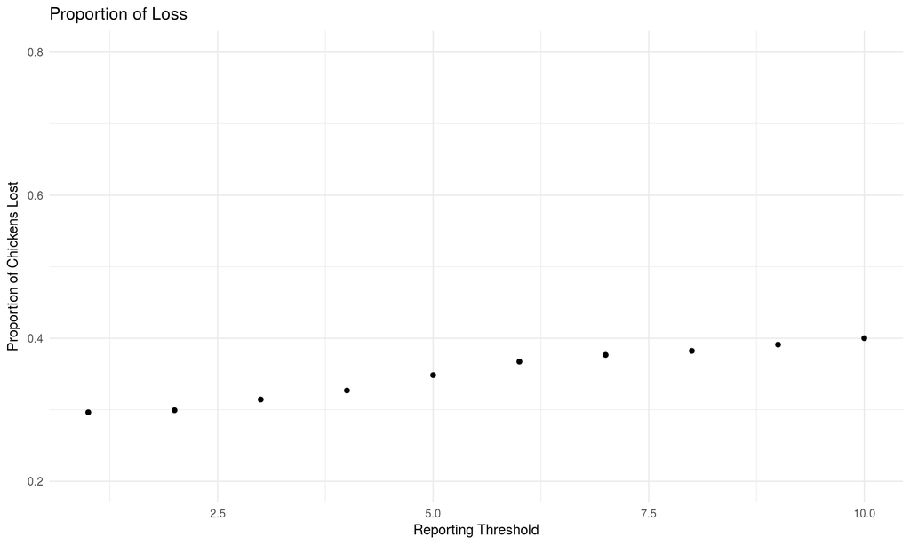

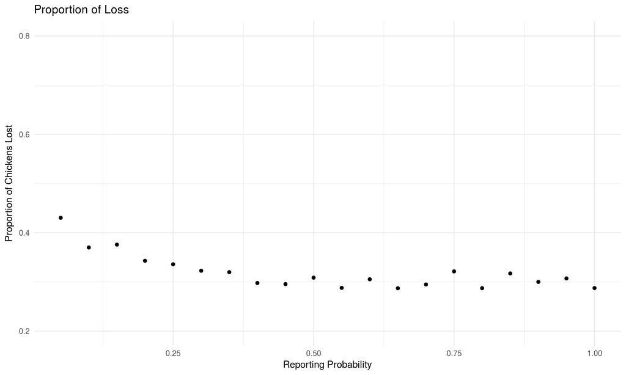

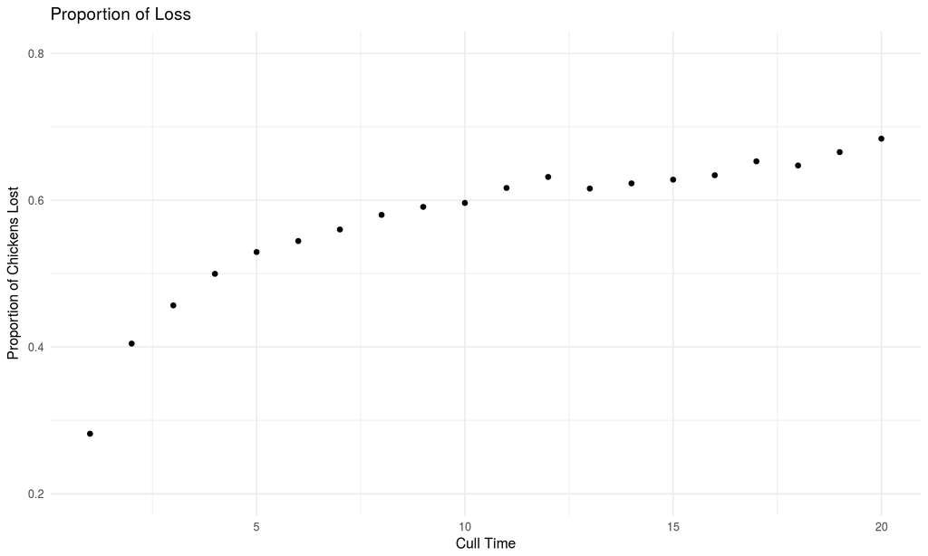

## Preliminary findings for varying farm size

Varying the farm size produces the same threshold behavior for culling: after a week, changes in t-detect don’t produce a noticeable difference, but there’s a strong correlation between lowering cull time and mitigating an outbreak under 7 days. This graph also shows a difference in outbreak severity for household farms (size ~50) versus larger commercial activity (200-1000 birds per farm), where more of the population was lost during an epidemic.

[interactive chart not shown]

## Culling at different intensity levels

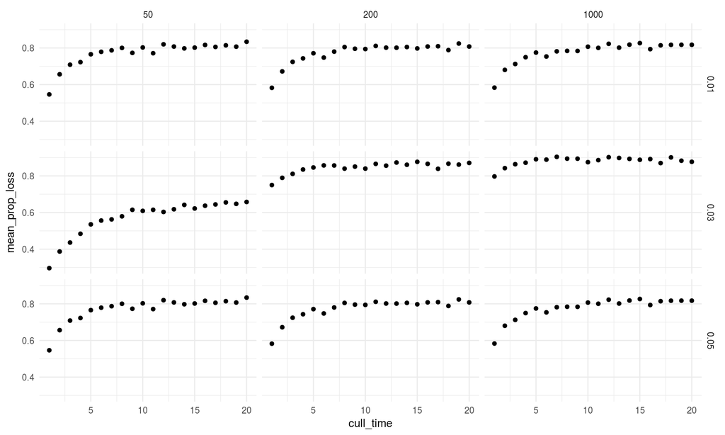